# 起薪与 AI 暴露度：一个被拆开后消失的零

TidyTuesday · 2026-10-20 (Week 42)

作者

zlZayn

发布于

2026年10月28日

# 一个被拆开后消失的零

≈ 0

285 个专业的起薪 × 总 AI 暴露度  
Pearson r = 0.0045（95% CI −0.11 ~ 0.12）

−0.16

语言任务暴露 × 起薪  
95% CI 不含 0（−0.27 ~ −0.04）

+0.33

图像任务暴露 × 起薪  
95% CI 不含 0（+0.22 ~ +0.43）

官方说明写这两个变量「几乎不相关（r 约为 0.01）」。我自己复算是 0.0045，那句话没错：这个零不是「没有关系」，是两股方向相反的关系抵消出来的。

把 AIOE 拆成语言任务与图像任务两支，一支向下（-0.155）、一支向上（0.331），两个置信区间都不含 0。

所以本周的主线不是「AI 暴露与薪资无关」，而是**「AI 暴露」这个大词把两件事压在了一起**，而这两件事在薪资上指向相反的方向。再往下一层，那个正号也大半来自「工科整体又高又贵」的组间差别，而不是同专业内部的关系。

## 一、先讲口径：285 个专业是怎么来的

285 个专业不是「所有专业」，而是**「起薪与 AIOE 两头都有值」的交集**：Scorecard 里有毕业一年后收入的 4 位 CIP，乘上 crosswalk 能连到至少一个带 AIOE 分数的职业，剩下的就是这 285 个。

底层是 1,505 条专业 × 职业连线，覆盖 463 个不同职业——下面所有暴露度数字都从这张表算出来。

四个必须先交代的口径：

1. **起薪不是「应届起薪」**，是毕业**一年后**的收入中位数；而且是院校级中位数的中位数。只有 27 个专业只来自 1 所院校、103 个不超过 10 所（中位 22 所），所以起薪的差距里混着「哪些院校开设这个专业」。
2. **AIOE 的 0 是「平均职业」，不是「平均专业」**。专业层面只有 31 个（10.9%）落在 0 以下，专业中位数是 1.035——crosswalk 连的都是专业技术岗，本来就比全职业平均更暴露。**所以原分数的正负不要当「安全 / 危险」的分界，要读 `ai_exposure_percentile`。**
3. **暴露度 ≠ 会被取代**。AIOE 量的是「这个职业需要的能力与 AI 能做的事重叠多少」，重叠可以是替代也可以是辅助；它不含岗位数量、工资弹性或时间表。
4. **`ai_exposure` 几乎就是语言那一支**：它与 `ai_exposure_language` 的相关是 0.958，与 `ai_exposure_image` 只有 0.697。这正是第三节要拆的理由。

表 1: 三个数据来源与各自的口径（本周只用这两份 CSV 的 13 + 7 列，不回溯原始 xlsx）

| 来源 | 在本页用到的列 | 口径 |
| --- | --- | --- |
| College Scorecard（美国教育部，field-of-study 文件） | median_starting_salary | 学士学位毕业一年后的收入中位数；院校级值再按 4 位 CIP 取中位数，不按毕业生人数加权 |
| AIOE（Felten, Raj & Seamans 2021） | ai_exposure, ai_exposure_language, ai_exposure_image | 职业（SOC）层面的标准化分数，均值 0、标准差 1；一个专业取其全部去向职业的算术平均 |
| NCES/BLS CIP2020 → SOC2018 crosswalk | cip4, soc（在 major_occupations.csv 里） | 把专业连到毕业生的常见职业；一个专业连 1 ~ 36 个职业 |

## 二、总暴露度与起薪：一条真正平的线

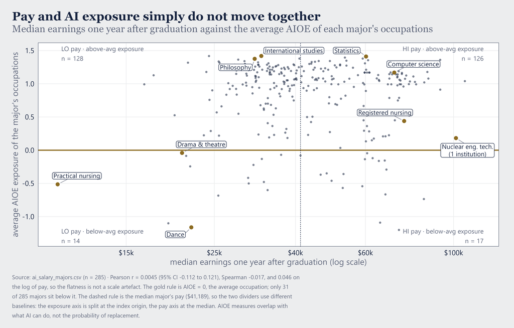

图 1: Starting pay and overall AI exposure are unrelated across 285 majors; the gold points are the nine majors named in the text and the quadrant counts are printed in each corner.

**横竖两条线的基准不一样**：竖线是中位起薪 $41,189，横线却是 AIOE 的原点 0，也就是「平均职业」，不是专业的中位数。这不是疏漏，是两把尺子各自的原点。

把横线挪到专业中位暴露度 1.035 再切一次，四象限仍然均分（见下表）。两种切法都不给结论，这正是「无关系」的样子。

但前者**只来自 1 所院校**，后者背后有 1,043 所院校、429,074 个毕业生。**同一档「低暴露、高薪」，证据强度完全不同**，读图时不该同等对待。

表 2: 四象限的原始数字，对应图 1（同一份 285 行的聚合；象限边界混用两种基准，见正文）

| 象限（竖线 = 中位起薪，横线 = AIOE 0） | 专业数 | 占比 | 象限内中位起薪 | 象限内中位暴露度 |
| --- | --- | --- | --- | --- |
| LO pay · above-avg exposure | 128 | 44.9% | 34,072 | 1.077 |
| HI pay · above-avg exposure | 126 | 44.2% | 59,671 | 1.071 |
| HI pay · below-avg exposure | 17 | 6.0% | 60,597 | -0.359 |
| LO pay · below-avg exposure | 14 | 4.9% | 27,996 | -0.448 |

表 3: 换一种切法：横线从 AIOE 0 挪到专业中位暴露度 1.035，四象限仍然均分（与上表同一批 285 个专业）

| 象限（竖线 = 中位起薪，横线 = 专业中位暴露度） | 专业数 | 占比 |
| --- | --- | --- |
| HI pay · above median exposure | 73 | 25.6% |
| LO pay · below median exposure | 72 | 25.3% |
| HI pay · below median exposure | 70 | 24.6% |
| LO pay · above median exposure | 70 | 24.6% |

## 三、拆开「AI 暴露」，两条反向的线

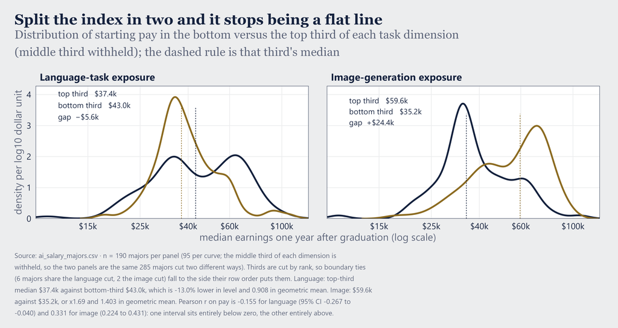

图 2: Language-task exposure and image-generation exposure pull starting pay in opposite directions: the top third by language exposure earns less than the bottom third, while the top third by image exposure earns about 1.7 times as much.

> raw 285 -> plotted 190 (两个维度各弃掉中间三分之一，各 95 个专业)

**读数**：语言暴露这一支是反的。上三分位的中位起薪 $37.4k，比下三分位的 $43.0k 少 5,598。**暴露更高的人反而赚得少。**

图像暴露则相反：$59.6k 对 $35.2k，1.69 倍。换成几何均值口径，方向一致（0.908 与 1.403）。

**两个维度不是同一个东西的两个刻度，而是两个方向相反的信号**——这就是把它们平均成一个 `ai_exposure` 之后相关归零的直接原因。

但这张图**不能**用来证明「图像任务暴露越高越挣得多」。它只把 285 个专业整体切三份，切出来的差别里有很大一块是组间差别：图像暴露高的专业集中在工科与建筑，而这些专业本来就薪高。下一节用组内相关直接检验。语言那一支虽不含 0，效应量只有 -0.155，属于「稳定但微弱」，不要读成「读语言类专业就完了」。

表 4: 两个任务维度的分位数字，对应图 2（美元；末列只有上三分位那一行有值，是相对同维度下三分位的几何均值倍数）

| 任务维度 | 三分位 | n | P25 | 中位数 | P75 | 几何均值倍数（上÷下） |
| --- | --- | --- | --- | --- | --- | --- |
| Language-task exposure | bottom third | 95 | 33,302 | 43,044 | 61,788 |  |
| Language-task exposure | top third | 95 | 32,640 | 37,446 | 46,069 | 0.908 |
| Image-generation exposure | bottom third | 95 | 32,218 | 35,228 | 48,456 |  |
| Image-generation exposure | top third | 95 | 41,467 | 59,620 | 72,185 | 1.403 |

## 四、那个「0」是四个组互相抵消出来的

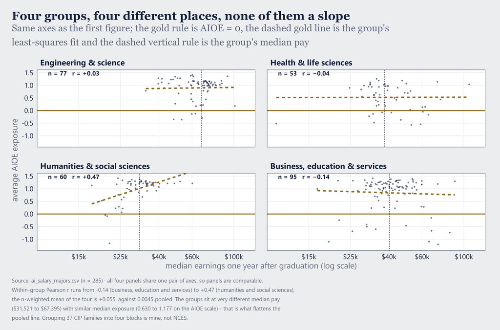

**读数**：四组的中位起薪从 $31,521（人文与社科）到 $67,395（工科与理科）。

**差 2.14 倍，中位暴露度却几乎并排。** 这就是整体相关被压平的全部机制：暴露度在组间没有系统差异，起薪有巨大的组间差异。

组内相关是另一回事：四个组的符号不一致（末三列见下表），加权后只有 +0.055。人文社科那一组是明确的正号，因为**这组里暴露度最低的恰是舞蹈、戏剧、纯艺这些起薪两万出头的艺术类专业**——「最不容易被 AI 碰到的人文学科」正好是最穷的那一半。官方那句「部分人文学科又低薪又高暴露」只对另一半成立。

图像那一支的正相关大半也是组间的：四个组的组内 r 都远低于池化的 +0.331，加权只剩 +0.110。**所以第三节那个 +0.33 主要是「工科整体又高又贵」，不是同专业之间的关系。**

表 5: 四个组的组内相关与中位数，对应图 3（r 为组内 Pearson，起薪取美元原值；末三列同源同批专业）

| 组（37 → 4，非官方分类） | 专业数 | 中位起薪 | 中位暴露度 | r（总暴露） | r（语言） | r（图像） |
| --- | --- | --- | --- | --- | --- | --- |
| Engineering & science | 77 | 67,395 | 1.049 | +0.035 | -0.035 | +0.249 |
| Health & life sciences | 53 | 37,946 | 0.630 | -0.039 | -0.057 | +0.028 |
| Humanities & social sciences | 60 | 31,521 | 1.177 | +0.465 | +0.421 | +0.134 |
| Business, education & services | 95 | 40,256 | 1.077 | -0.137 | -0.203 | +0.028 |

表 6: 分组合并规则明细（左侧 37 个 CIP 大类折成 4 组，是我为读图做的合并，不是 NCES 分类；加起来 = 285）

| 组 | 所含 CIP 大类 | 专业数 |
| --- | --- | --- |
| Engineering & science | Computer Science · Engineering · Engineering Tech · Mathematics & Statistics · Physical Sciences · Science Tech | 77 |
| Health & life sciences | Agriculture · Biological Sciences · Health Professions · Natural Resources | 53 |
| Humanities & social sciences | Area & Ethnic Studies · Communication · Communications Tech · English · Foreign Languages · History · Library Science · Philosophy & Religion · Psychology · Social Sciences · Theology & Religion · Vis… | 60 |
| Business, education & services | Architecture · Business · Construction Trades · Culinary & Personal Svc · Education · Family & Consumer Sci · Homeland Security · Interdisciplinary · Legal · Mechanic & Repair Tech · Military Tech · P… | 95 |

## 五、专业的暴露度是其职业的平均

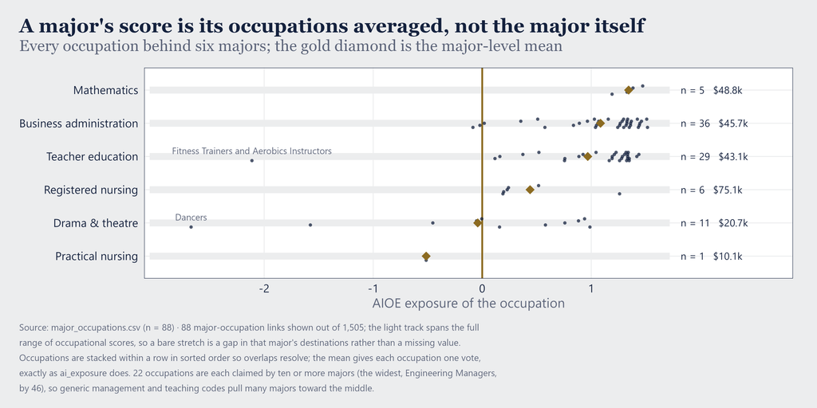

图 4: Each major’s exposure score is the plain average of the occupations it feeds: drama averages a dancer score of -2.67 with a writer score of +0.99, while practical nursing averages a single occupation and mathematics averages five that all sit near the top.

**读数**：`Drama & theatre` 的 11 个职业从 -2.67（`Dancers`）到 0.99（`Writers and Authors`）。

跨度 3.66，而专业级均值只有 -0.041——**它看起来落在「不暴露」的中段，纯粹是平均的产物**。

`Teacher education` 更宽：29 个职业从 -2.11（`Fitness Trainers and Aerobics Instructors`）到 1.44（历史、英语这类学科教师）。

反方向的极端是 `Mathematics`：5 个职业全挤在 1.19 ~ 1.47。跨度只有 0.28，所以它的均值是稳的。`Practical nursing` 只连 1 个职业，分值就是 `Licensed Practical and Licensed Vocational Nurses` 的原值，没有平均。

**同一列里，有的值是 36 个职业的平均，有的就是单职业的原值**——这就是为什么百分位差十分以内不值得当真，也是为什么 `n_occupations` 必须和暴露度一起读。

还有个量表层面的提醒：22 个职业各被 10 个以上专业共用，最多的 Engineering Managers 被 46 个专业共用。这些通用管理与教师代码把一批专业往中间拉，专业之间的独立信息因此比 285 这个数字听起来少。

表 7: 六个专业的职业分布数字，对应图 4（6 个专业、88 条专业×职业连线；跨度为 max − min，均值即 ai_salary_majors 的 ai_exposure）

| 专业 | 职业数 | 最低 | 最高 | 跨度 | 均值（即 ai_exposure） | 起薪 |
| --- | --- | --- | --- | --- | --- | --- |
| Practical nursing | 1 | -0.51 | -0.51 | 0.00 | -0.514 | 10,084 |
| Drama & theatre | 11 | -2.67 | 0.99 | 3.66 | -0.041 | 20,732 |
| Registered nursing | 6 | 0.19 | 1.26 | 1.07 | 0.439 | 75,093 |
| Teacher education | 29 | -2.11 | 1.44 | 3.55 | 0.968 | 43,093 |
| Business administration | 36 | -0.08 | 1.52 | 1.60 | 1.085 | 45,717 |
| Mathematics | 5 | 1.19 | 1.47 | 0.28 | 1.343 | 48,828 |

## 六、这份数据站不住脚的几处

[output not shown]

## 方法与口径

| 项 | 值 |
| --- | --- |
| 数据 | `data/ai_salary_majors.csv`（285 × 13，一行一专业，`cip4` 唯一）；`data/major_occupations.csv`（1,505 × 7） |
| 覆盖 | 285 个学士专业 / 463 个 SOC 职业 / 37 个 CIP 大类；`n_graduates` 合计 2,431,833 |
| 入图样本 | 图 1 / 3 用全部 285；图 2 每个维度 raw 285 -> plotted 190 (弃掉该维度中间三分之一)；图 4 只画 6 个专业 |
| 起薪口径 | `median_starting_salary` = 毕业一年后收入中位数，院校级值的**未加权中位数**；不是应届、不是生涯起薪，也不按毕业生人数加权 |
| 暴露口径 | `ai_exposure` = 该专业全部去向职业 AIOE 的**算术平均**（`n_occupations` 见各表）；AIOE 已标准化（均值 0、SD 1），0 = 平均职业 |
| 相关性口径 | 全部为 Pearson；Spearman 与 log 起薪两档作为替换检验写在图 1；置信区间用 Fisher z 变换，未对分组或机构规模做任何调整 |
| 分组口径 | 37 个 `broad_field_short` 折成 4 组是我为读图做的合并，**不是 NCES 分类**；规则摊在第四节的「分组合并规则明细」表里 |
| 不作为证据的列 | `ai_exposure_percentile`（与 `ai_exposure` 同源，只换刻度）；`median_salary_4yr`（缺失集中在单机构专业，且与 1 年列不同口径）；`n_institutions` / `n_graduates` 只用来给结论定权重，不做自变量 |
| 明确不画的东西 | 不画 37 个 `broad_field_short` 的逐类排名（多数类不足 5 个专业，排的是抽样噪声）；不画国家或院校层面（数据里没有）；不画时间趋势（Scorecard 快照只有一个版本）；不把暴露度画成「安全 / 危险」二分（AIOE 不含替代概率，二分等于替数据下结论） |
| 数字来源 | 正文每个内联数字都来自本页分析代码的同一份聚合，经 `sprintf` / `format` 定型 |